# Red Wine Quality : An Exploratory Data Analysis by Nupur Shukla

### Introduction

The objective of this analyis is to use Exploratory Data Analysis techniques to find “Which chemical properties influence the quality of wine ?” Being a wine enthusiast myself, I have experienced the price of wine largely depends on it’s propularity otr appreciation in the social circle.I chose this dataset for analysis because I am interested to see whether human tasting can be related to the chemical properties of wine. This analysis can be used to further build a predictive model which can provide guidance to vineyards regarding the price and quality of of their wines.

**The Data Set**

This tidy data set contains 1,599 red wines with 11 variables on the chemical properties of the wine. At least 3 wine experts rated the quality of each wine, providing a rating between 0 (very bad) and 10 (very excellent).

**Summary of the Data Set**

```
##  [1] "X"                    "fixed.acidity"        "volatile.acidity"
##  [4] "citric.acid"          "residual.sugar"       "chlorides"
##  [7] "free.sulfur.dioxide"  "total.sulfur.dioxide" "density"
## [10] "pH"                   "sulphates"            "alcohol"
## [13] "quality"
```

```
## 'data.frame':    1599 obs. of  13 variables:
##  $ X                   : int  1 2 3 4 5 6 7 8 9 10 ...
##  $ fixed.acidity       : num  7.4 7.8 7.8 11.2 7.4 7.4 7.9 7.3 7.8 7.5 ...
##  $ volatile.acidity    : num  0.7 0.88 0.76 0.28 0.7 0.66 0.6 0.65 0.58 0.5 ...
##  $ citric.acid         : num  0 0 0.04 0.56 0 0 0.06 0 0.02 0.36 ...
##  $ residual.sugar      : num  1.9 2.6 2.3 1.9 1.9 1.8 1.6 1.2 2 6.1 ...
##  $ chlorides           : num  0.076 0.098 0.092 0.075 0.076 0.075 0.069 0.065 0.073 0.071 ...
##  $ free.sulfur.dioxide : num  11 25 15 17 11 13 15 15 9 17 ...
##  $ total.sulfur.dioxide: num  34 67 54 60 34 40 59 21 18 102 ...
##  $ density             : num  0.998 0.997 0.997 0.998 0.998 ...
##  $ pH                  : num  3.51 3.2 3.26 3.16 3.51 3.51 3.3 3.39 3.36 3.35 ...
##  $ sulphates           : num  0.56 0.68 0.65 0.58 0.56 0.56 0.46 0.47 0.57 0.8 ...
##  $ alcohol             : num  9.4 9.8 9.8 9.8 9.4 9.4 9.4 10 9.5 10.5 ...
##  $ quality             : int  5 5 5 6 5 5 5 7 7 5 ...
```

```
##  fixed.acidity   volatile.acidity  citric.acid    residual.sugar
##  Min.   : 4.60   Min.   :0.1200   Min.   :0.000   Min.   : 0.900
##  1st Qu.: 7.10   1st Qu.:0.3900   1st Qu.:0.090   1st Qu.: 1.900
##  Median : 7.90   Median :0.5200   Median :0.260   Median : 2.200
##  Mean   : 8.32   Mean   :0.5278   Mean   :0.271   Mean   : 2.539
##  3rd Qu.: 9.20   3rd Qu.:0.6400   3rd Qu.:0.420   3rd Qu.: 2.600
##  Max.   :15.90   Max.   :1.5800   Max.   :1.000   Max.   :15.500
##    chlorides       free.sulfur.dioxide total.sulfur.dioxide
##  Min.   :0.01200   Min.   : 1.00       Min.   :  6.00
##  1st Qu.:0.07000   1st Qu.: 7.00       1st Qu.: 22.00
##  Median :0.07900   Median :14.00       Median : 38.00
##  Mean   :0.08747   Mean   :15.87       Mean   : 46.47
##  3rd Qu.:0.09000   3rd Qu.:21.00       3rd Qu.: 62.00
##  Max.   :0.61100   Max.   :72.00       Max.   :289.00
##     density             pH          sulphates         alcohol
##  Min.   :0.9901   Min.   :2.740   Min.   :0.3300   Min.   : 8.40
##  1st Qu.:0.9956   1st Qu.:3.210   1st Qu.:0.5500   1st Qu.: 9.50
##  Median :0.9968   Median :3.310   Median :0.6200   Median :10.20
##  Mean   :0.9967   Mean   :3.311   Mean   :0.6581   Mean   :10.42
##  3rd Qu.:0.9978   3rd Qu.:3.400   3rd Qu.:0.7300   3rd Qu.:11.10
##  Max.   :1.0037   Max.   :4.010   Max.   :2.0000   Max.   :14.90
##     quality
##  Min.   :3.000
##  1st Qu.:5.000
##  Median :6.000
##  Mean   :5.636
##  3rd Qu.:6.000
##  Max.   :8.000
```

**Observations**

For most the input variables( all excluding ‘quality’) the mean is greater than the median.This indicates there maybe outliers in the dataset. It is interesting to see some wine have no citric acid, which are often added for ‘freshness’ and flavor.

# Univariate Plots Section

**Historams showing variable distribution**

Next, I will look at the univariate analysis and investigate variables individually to look for unusual data and patterns for futher analysis.

```
##    Min. 1st Qu.  Median    Mean 3rd Qu.    Max.
##   3.000   5.000   6.000   5.636   6.000   8.000
```

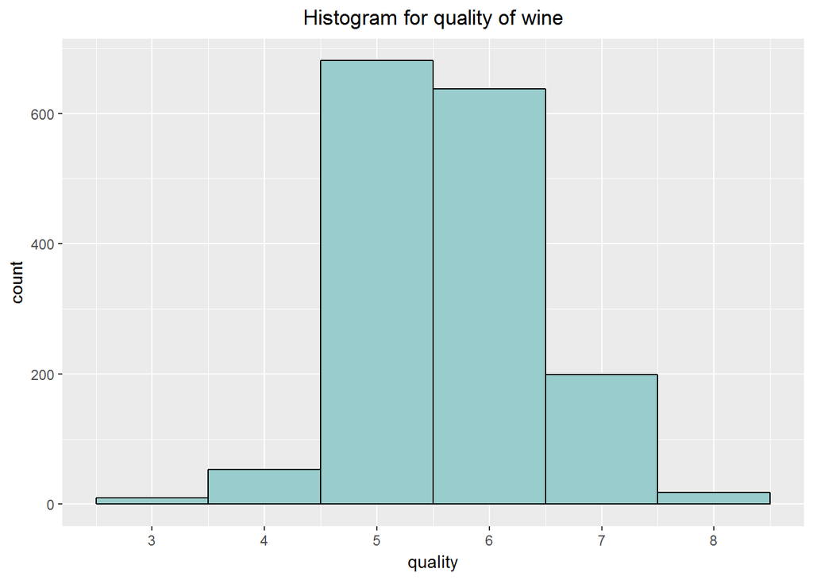

The distribution for Quality appears to be unimodal and normal with most values concentrated in categories 5 and 6. The wine scores are in the range [3,8].

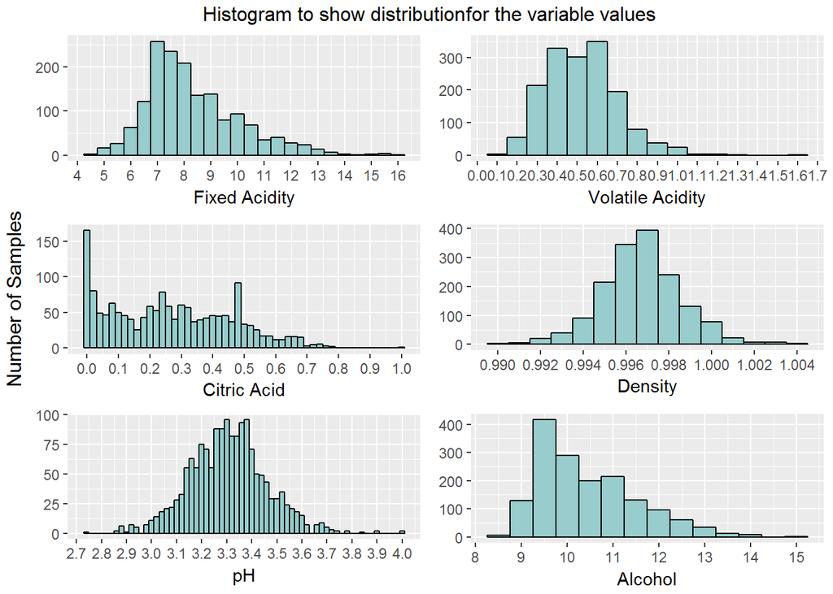

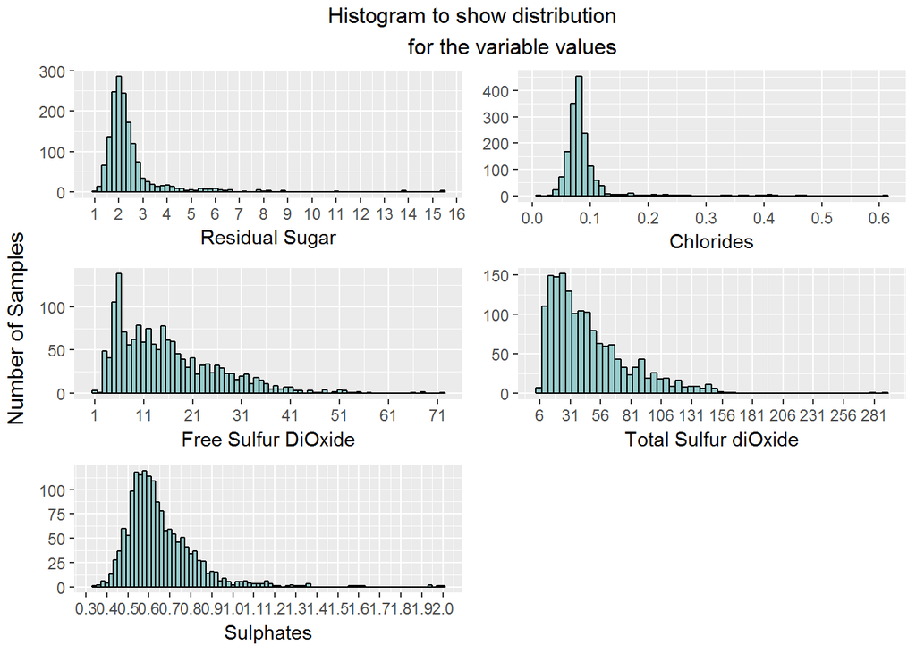

**Boxplots for each of the variables as another indicator of spread**

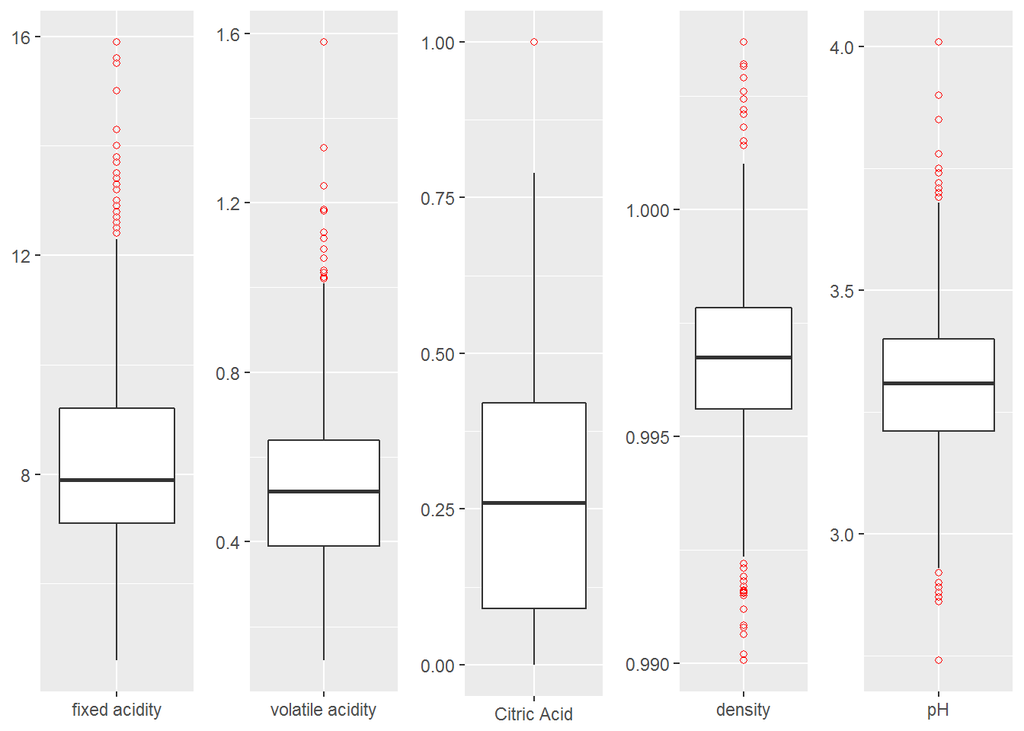

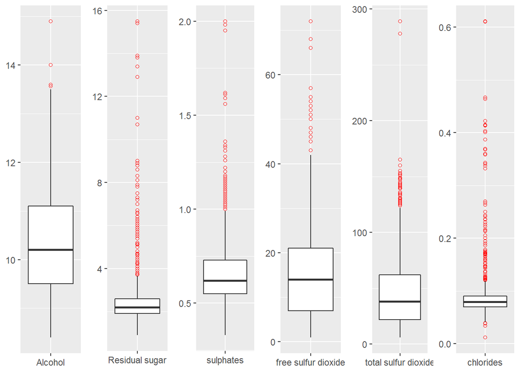

**Observations from the plots above :**

- All variables have outliers and most outliers are on the larger side.
- Residual Sugar, Chlorides, Free Sulfur Dioxide, Total Sulfur Dioxide  
  and Sulphates have a positively skewed distribution with quite a few outliers the larger side.Using a log transformation of these variables may help to fit these distributiontions into a more normal model or bell curve.
- Fixed Acidity follows a normal distribution in the range [4.6 g/dm3, 15.9 g/dm3]. 50% of the data is between 4.6 g/dm3 and 7.90 g/dm3.
- *Volatile Acidity* has a slighly right skewed normal distribution with a tail on the right side of the plot. The mean and median values are almost equal(0.52 g/dm3).
- Citric Acid has it’s median at 0.26 and mean at 0.271.There are two main  
  peaks in the plot between [0,0.02] and [0.48,0.5].According to the histogram, maximum number of wines do not contain citric acid. The Data requires transformation to better understand the distribution.
- Alcohol has a strong right skew but less outliers compared to other right skewed variables.
- pH and Density have a fairly normal distribution.

**Transforming data**

In order to reduce the skewness of variables; Residual Sugar, Chlorides, Free Sulfur Dioxide, Total Sulfur Dioxide and Sulphates a log transformation is applied to make this distribution more “Normal”. Skew data can be transformed to have a more normal distribution (ideal for linear or logistic regression model ) using log or square root transformation techniques. The histogram for Citirc Acid shows the distribution is not normal, a log transformation resulted in a left skewed distribution for this variable so I have applied a square root transformation to get a more normal looking plot except the spike at 0. The plots can be found below :

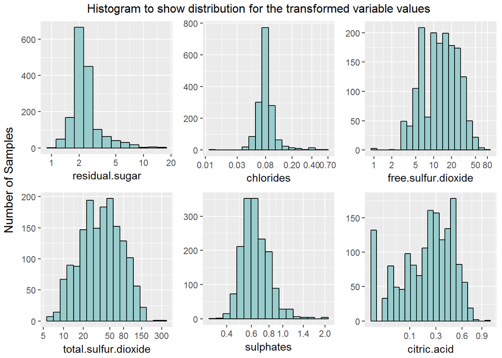

Internet articles suggest a good sign of quality is balance.A wine is balanced when all of the wine’s components (e.g. sweetness, acidity, tannins, alcohol) blend together. The balance or potential to be balanced after ageing is a sign of quality. Next, Let’s create a categorical variable to distinguish ‘loW’(score<5), ‘medium’(5==8) quality wines.

```r
# Adding a new feature wine_category which distinguishes wines into 3 categories
red_wine$wine_category<-0
red_wine$wine_category<-ifelse(red_wine$quality<5,'low',red_wine$wine_category)
red_wine$wine_category<-ifelse((red_wine$quality>=5 & red_wine$quality<7) ,
                               'medium',red_wine$wine_category)
red_wine$wine_category<-ifelse(red_wine$quality>=7 ,'high',
                               red_wine$wine_category)
red_wine$wine_category<-ordered(red_wine$wine_category,levels=c('low','medium',
                                                                'high'))
```

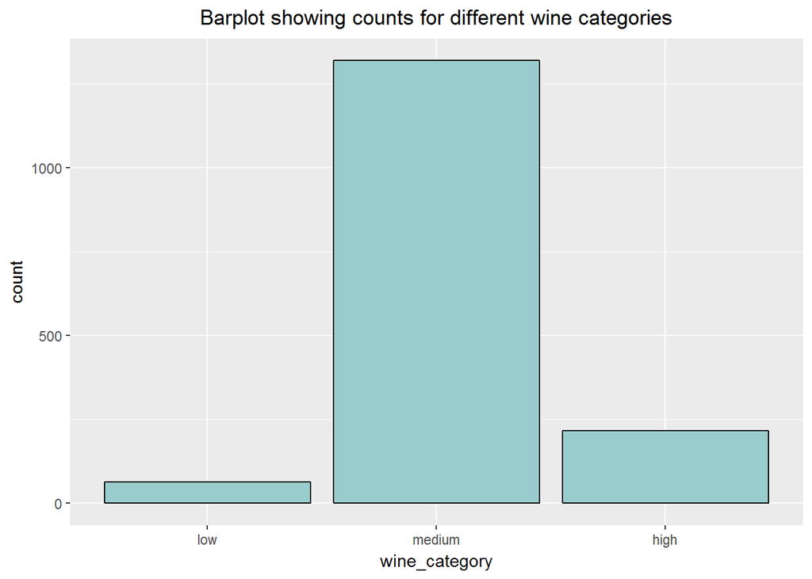

The Barplot above clearly indicates that maximum samples in this data set are of medium quality. Since, quality is indicating the wine category I will now convert quality into a factor variable.

```r
red_wine$quality_factor<-factor(red_wine$quality)
```

# Univariate Analysis

### What is the structure of your dataset?

There are 1599 red wine in this data set with 12 features (fixed.acidity, volatile.acidity, citric.acid, residual.sugar, chlorides, free.sulfur.dioxide, total.sulfur.dioxide, density, pH, sulphates and quality).The Univariate plots above show most features observe a normal distribution but some outliers

### What is/are the main feature(s) of interest in your dataset?

The focus of this analysis is to identify the features that influence the  
quality of wine which makes it the most important feature in this data set. However, a good quality wine has a balance of sweetness( residual sugar ), acidity( fixed acidity + volatile acidity) and alcohol( alcohol) level. I would like to find out which features are strongly correlated with quality in further sections.

### What other features in the dataset do you think will help support your investigation into your feature(s) of interest?

Other than features mentioned previously, density (dependent on alcohol and sugar content) and sulfur dioxide(both free and total) are likely to contribute to the quality of wine.

### Did you create any new variables from existing variables in the dataset?

wine_category a categorical variable to distinguish ‘low’(score<5), ‘medium’ (5==8) quality wines. quality_factor as another categorical variable.

### Of the features you investigated, were there any unusual distributions? Did you perform any operations on the data to tidy, adjust, or change the form of the data? If so, why did you do this?

Yes,in order to reduce the skewness of variables; Residual Sugar, Chlorides, Free Sulfur Dioxide, Total Sulfur Dioxide, Sulphates and Citric Acid a log /square root transformation is applied to obtain a normal or close to normal distribution.

# Bivariate Plots Section

**Correlation Matrix**

Next, we look at the correlation matrix for the datasset to find relationships between features.

```
##                      fixed.acidity volatile.acidity citric.acid
## fixed.acidity           1.00000000     -0.256130895  0.67170343
## volatile.acidity       -0.25613089      1.000000000 -0.55249568
## citric.acid             0.67170343     -0.552495685  1.00000000
## residual.sugar          0.11477672      0.001917882  0.14357716
## chlorides               0.09370519      0.061297772  0.20382291
## free.sulfur.dioxide    -0.15379419     -0.010503827 -0.06097813
## total.sulfur.dioxide   -0.11318144      0.076470005  0.03553302
## density                 0.66804729      0.022026232  0.36494718
## pH                     -0.68297819      0.234937294 -0.54190414
## sulphates               0.18300566     -0.260986685  0.31277004
## alcohol                -0.06166827     -0.202288027  0.10990325
## quality                 0.12405165     -0.390557780  0.22637251
##                      residual.sugar    chlorides free.sulfur.dioxide
## fixed.acidity           0.114776724  0.093705186        -0.153794193
## volatile.acidity        0.001917882  0.061297772        -0.010503827
## citric.acid             0.143577162  0.203822914        -0.060978129
## residual.sugar          1.000000000  0.055609535         0.187048995
## chlorides               0.055609535  1.000000000         0.005562147
## free.sulfur.dioxide     0.187048995  0.005562147         1.000000000
## total.sulfur.dioxide    0.203027882  0.047400468         0.667666450
## density                 0.355283371  0.200632327        -0.021945831
## pH                     -0.085652422 -0.265026131         0.070377499
## sulphates               0.005527121  0.371260481         0.051657572
## alcohol                 0.042075437 -0.221140545        -0.069408354
## quality                 0.013731637 -0.128906560        -0.050656057
##                      total.sulfur.dioxide     density          pH
## fixed.acidity                 -0.11318144  0.66804729 -0.68297819
## volatile.acidity               0.07647000  0.02202623  0.23493729
## citric.acid                    0.03553302  0.36494718 -0.54190414
## residual.sugar                 0.20302788  0.35528337 -0.08565242
## chlorides                      0.04740047  0.20063233 -0.26502613
## free.sulfur.dioxide            0.66766645 -0.02194583  0.07037750
## total.sulfur.dioxide           1.00000000  0.07126948 -0.06649456
## density                        0.07126948  1.00000000 -0.34169933
## pH                            -0.06649456 -0.34169933  1.00000000
## sulphates                      0.04294684  0.14850641 -0.19664760
## alcohol                       -0.20565394 -0.49617977  0.20563251
## quality                       -0.18510029 -0.17491923 -0.05773139
##                         sulphates     alcohol     quality
## fixed.acidity         0.183005664 -0.06166827  0.12405165
## volatile.acidity     -0.260986685 -0.20228803 -0.39055778
## citric.acid           0.312770044  0.10990325  0.22637251
## residual.sugar        0.005527121  0.04207544  0.01373164
## chlorides             0.371260481 -0.22114054 -0.12890656
## free.sulfur.dioxide   0.051657572 -0.06940835 -0.05065606
## total.sulfur.dioxide  0.042946836 -0.20565394 -0.18510029
## density               0.148506412 -0.49617977 -0.17491923
## pH                   -0.196647602  0.20563251 -0.05773139
## sulphates             1.000000000  0.09359475  0.25139708
## alcohol               0.093594750  1.00000000  0.47616632
## quality               0.251397079  0.47616632  1.00000000
```

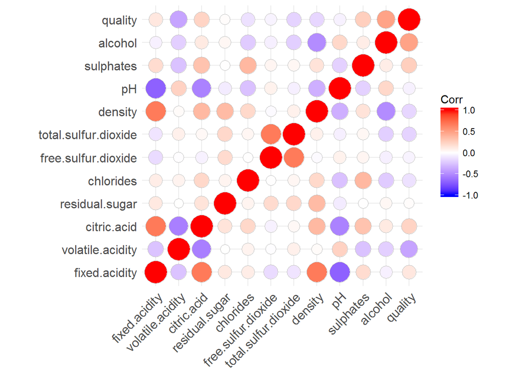

The Correlation Matrix output suggests the following:

- Alcoholshows a strong positive correlation with quality followed by sulphates and citric Acid .
- Volatile acidity responsible for unpleasant smell in wines has a strong negative correlation with quality. It also shows a negative correlation with citric Acid.
- Fixed Acidity shows a positive correlation with citric acid (fixed acid component) and density. It also shows a negative correlation with pH and Volatile acidity.
- Free sulfur dioxide shows a strong positive correlation with total sulfur di oxide.

Below are some plots summarising the relationships between features:

** Quality vs Alcohol **

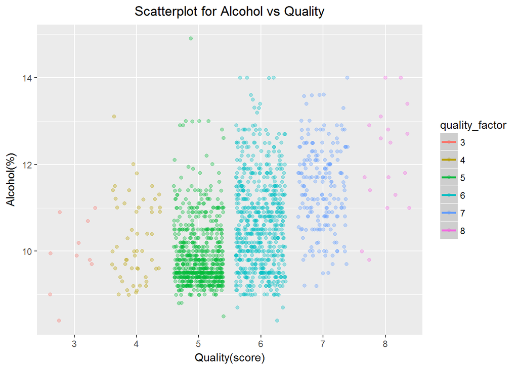

The plot above clearly shows a positive relationship between alcohol(% by volume )and quality score.

**Summary of alcohol content grouped by wine category**

```
## # A tibble: 3 x 4
##   wine_category mean_alcohol median_alcohol max_alcohol
##           <ord>        <dbl>          <dbl>       <dbl>
## 1           low     10.21587           10.0        13.1
## 2        medium     10.25272           10.0        14.9
## 3          high     11.51805           11.6        14.0
```

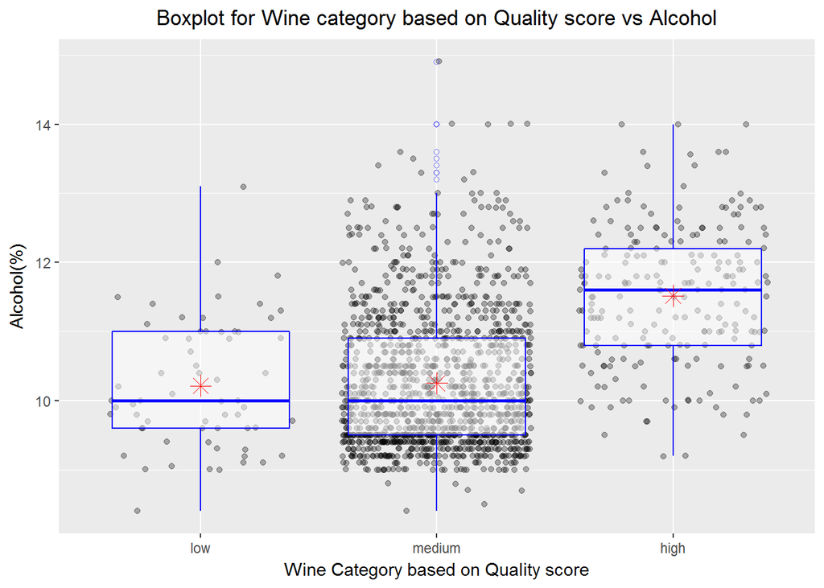

*Alcohol* content does not show an strong significance in quality prediction. Both low and medium quality wines have 50% of samples containing more than 10% by volume alcohol content. Box plot for medium quality wines show some outliers (high alcohol content) with maximum content of about 14.9% by vol. which is greater than the maximum alcohol content found in high quality wines of 14% by vol. However, for both low and medium quality wines the median is more samples have low alcohol content whereas fro high quality wines more sameples have high alcohol content.

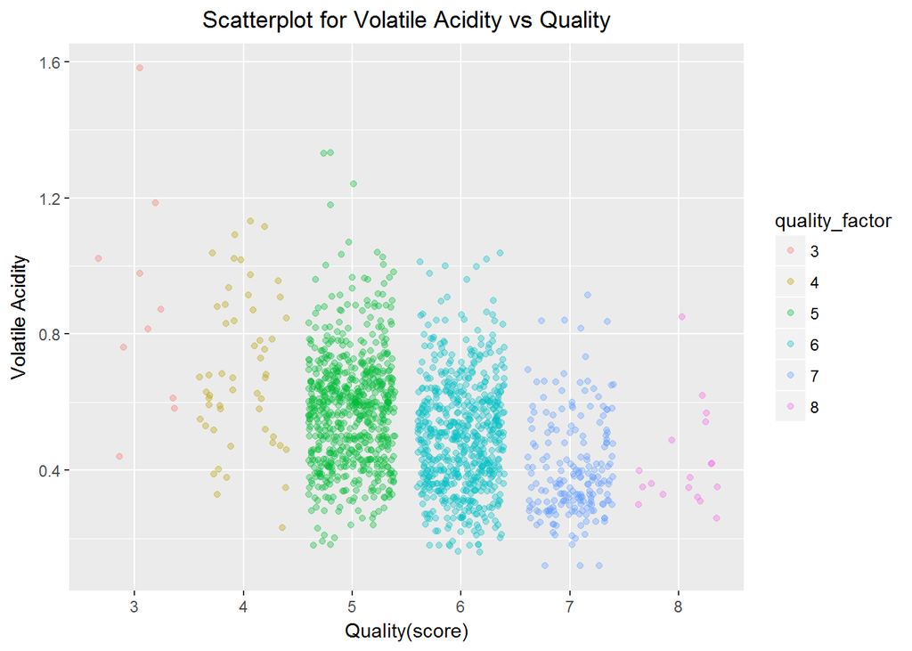

Plot above shows a negative correlation between volatile acidity and wine quality.

```r
red_wine %>%
  group_by(wine_category) %>%
  summarise(mean_volatile_acidity=mean(volatile.acidity),
           median_volatile_acidity=median(volatile.acidity),
           sd_volatile_acidity=sd(volatile.acidity))
```

```
## # A tibble: 3 x 4
##   wine_category mean_volatile_acidity median_volatile_acidity
##           <ord>                 <dbl>                   <dbl>
## 1           low             0.7242063                    0.68
## 2        medium             0.5385595                    0.54
## 3          high             0.4055300                    0.37
## # ... with 1 more variables: sd_volatile_acidity <dbl>
```

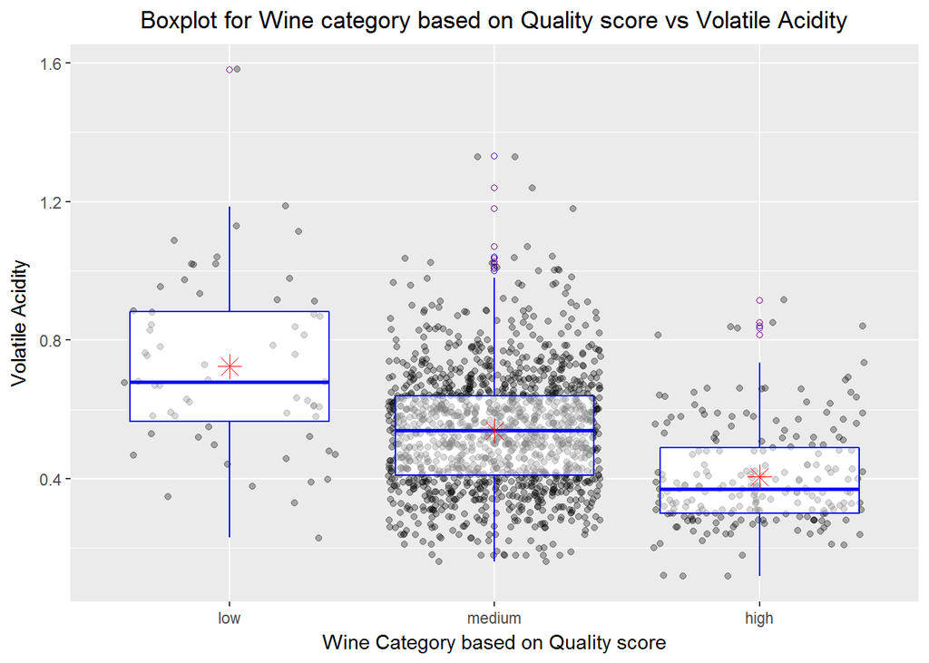

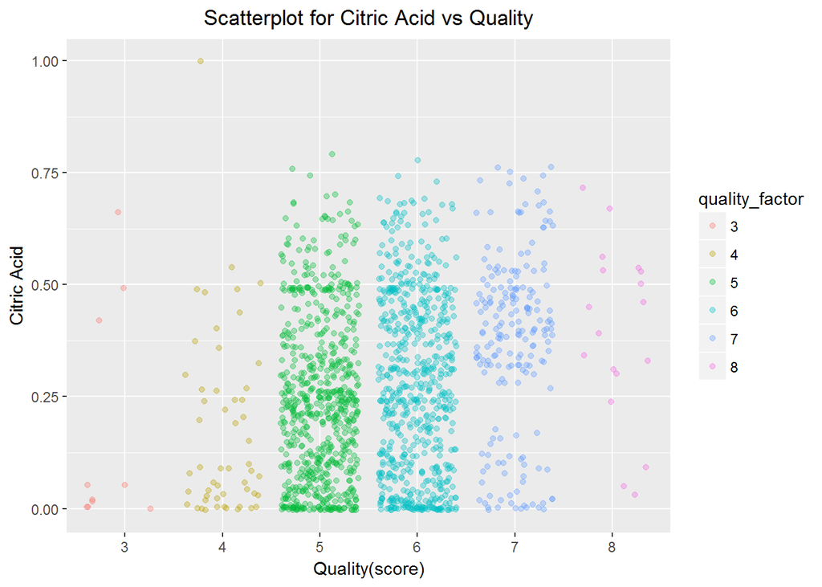

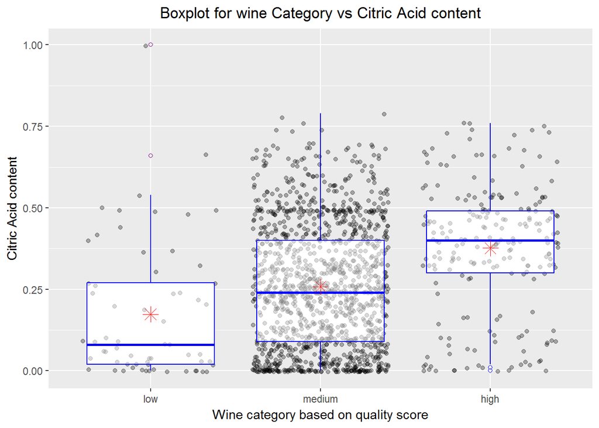

The scatter plot and box plot for citirc acid vs quality show positive correlation between the features. The box plot for citric acid shows very less outliers compared to other plots and might be used for prediction of quality.

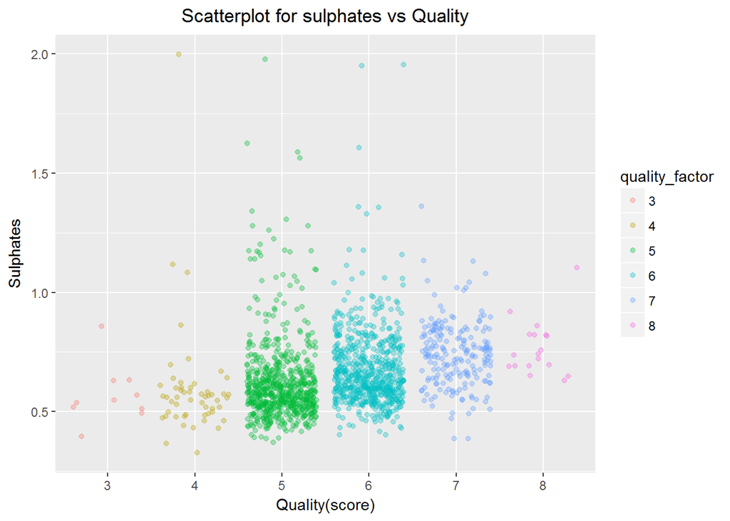

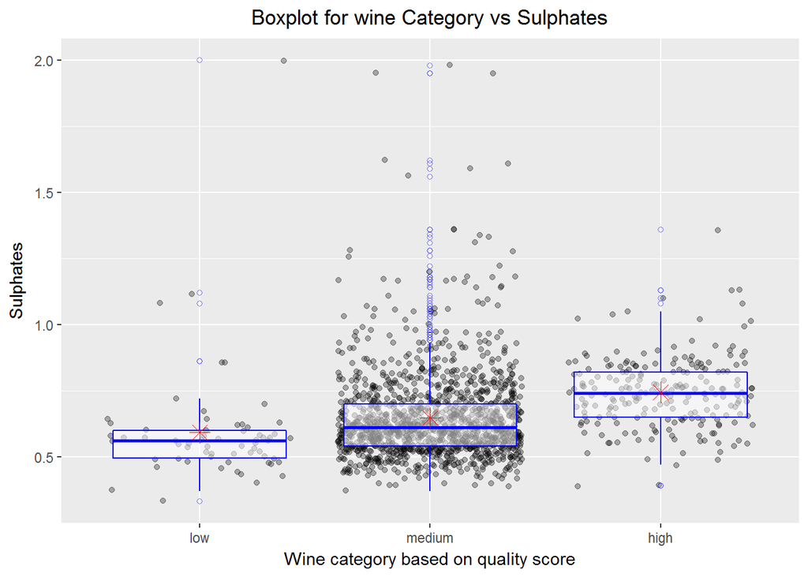

The plots for sulphates vs quality show a positive relationship but most outliers are in medium quality wines. Next, the plots below summarize relationships betweeen features other than quality.

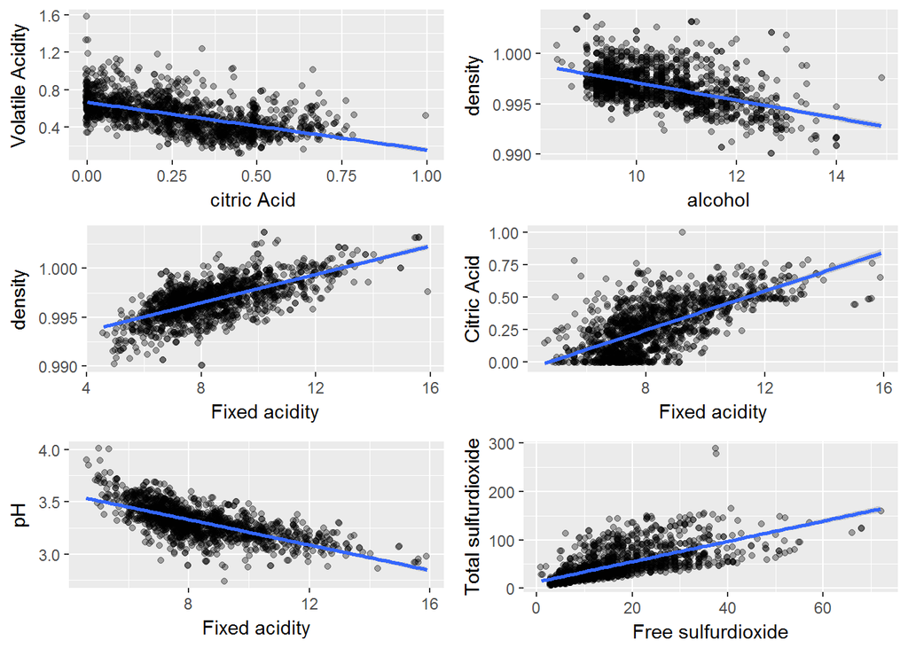

# Bivariate Analysis

### Talk about some of the relationships you observed in this part of the investigation. How did the feature(s) of interest vary with other features in the dataset?

*Alcohol content for high quality wines seems to be high but does not have any significant bias.* Density and alcohol content have a negative relationship. Samples with less density have more alcohol content. *Fixed acidity is storngly correlated with pH, density and Citric Acid.* Wine samples with high sulphates have higher quality. Sulphates show a positive correlation with quality but there are significant number of outliers.

### Did you observe any interesting relationships between the other features (not the main feature(s) of interest)?

Residual sugar, chlorides and sulphates do not show any significant relationships with any other feature. Some of the strongest correlations are between chemical attribute variables, and not the main feature of interest(quality). There is a strong positive relationship between *fixed acidity* and *density*, *free sulfur dioxide* and *total sulfur dioxide*, *citric acid* and *fixed acidity*. *Volatile acidity* and *citric acid*, *fixed acidity* and *pH*, *alcohol* and *density* show strong negative relationships.

### What was the strongest relationship you found?

*Alcohol* shows the strongest association with feature of interest, *quality* (r-squared=0.476).Among other features *pH* and *fixed acidity* show highest correlation (r-squared=-0.683)

# Multivariate Plots Section

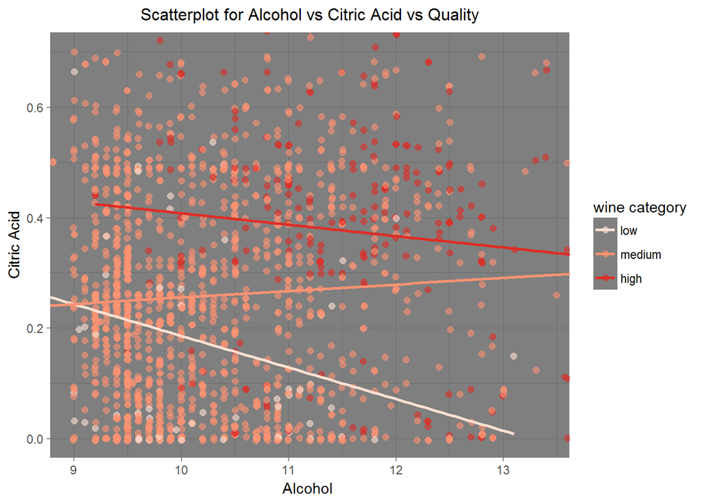

We can see in the above plot that high quality wines are spreadout in the region where alcohol>=10 and samples become more concentrated when citric acid content is more that 0.3 (Approx.).

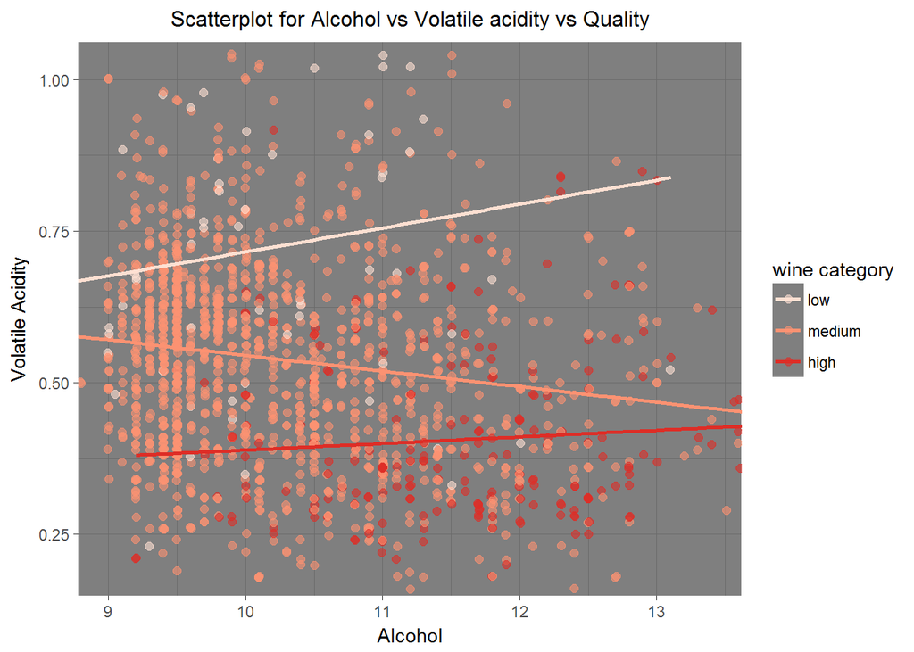

*Alcohol* and *Volatile acidity* have the strongest positive and negative correlation with quality, respectively. There is a fairly clear separation between the low quality wines(upper left) and high quality wines(lower right) but the medium quality wines are spreadout throughout. Hence, a model with these two features alone will not be a good predictor of wine quality.

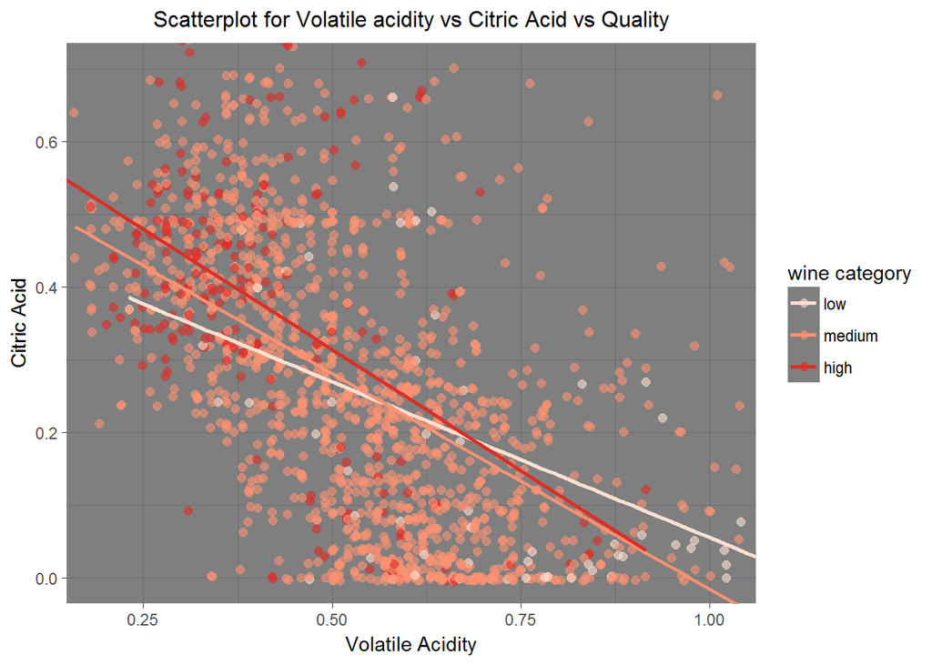

```r
ggplot(red_wine, aes(x=volatile.acidity,y=citric.acid,color=wine_category))+
  geom_jitter(alpha=0.6,size=2)+
  coord_cartesian(
    xlim = c(quantile(red_wine$volatile.acidity, .01),
             quantile(red_wine$volatile.acidity, .99)),
    ylim = c(quantile(red_wine$citric.acid, .01),
             quantile(red_wine$citric.acid, .99))
    )+
  theme_dark()+
   geom_smooth(method="lm",se=FALSE,size=1)+
  scale_color_brewer(palette="Reds",guide=guide_legend(title='wine category'))+
  ggtitle("Scatterplot for Volatile acidity vs Citric Acid vs Quality")+
  theme(plot.title=element_text(hjust=0.5,size=12))+
  ylab("Citric Acid")+
  xlab("Volatile Acidity")
```

In the graph above, low quality wines have lower values for citric acid and higher volatile acidity, and high quality wines have high ctric acid values but low volatile acidity.

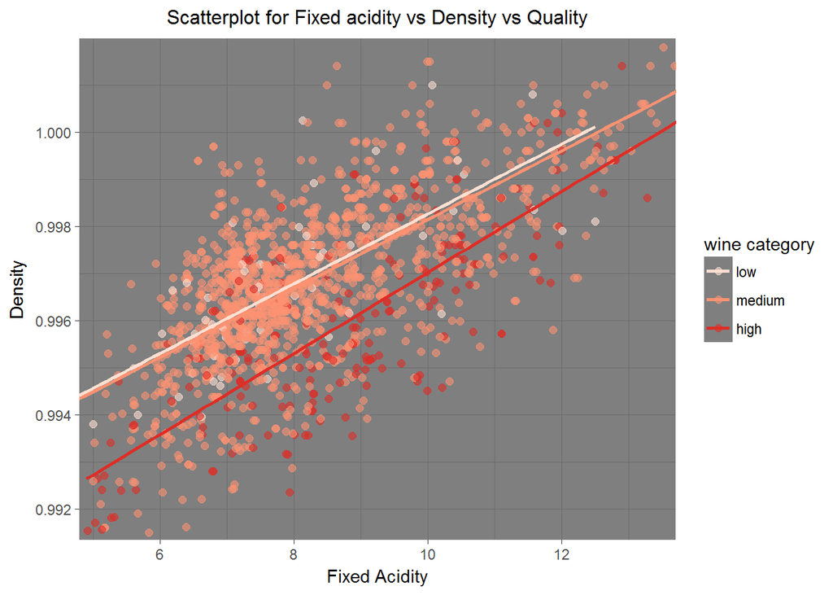

This graph reveals an interesting pattern where low and medium quality wines fall more towards the upper left side of the graph while high quality wines fall more towards the lower right side of the graph. Higher quality wines will have lower density value.

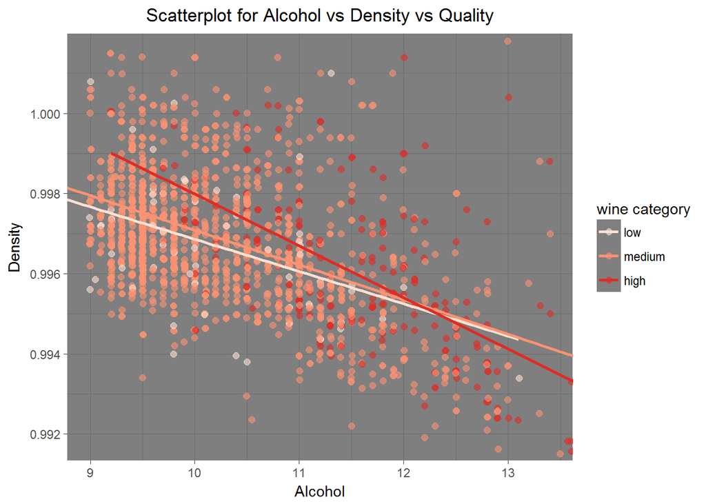

As discovered previously high quality wines have more alcohol content and lower density values. The graph above confirms this trend in the features.

**Regression Model**

I will now create a linear regression model to predict wine quality.All variables are added to the model in progression( according to their relationship with quality).

```r
m1<-lm(data=red_wine,quality~volatile.acidity)
m2<-update(m1,~.+alcohol)
m3<-update(m2,~.+sulphates)
m4<-update(m3,~.+citric.acid)
m5<-update(m4,~.+chlorides+total.sulfur.dioxide+density+fixed.acidity)
mtable(m1,m2,m3,m4,m5)
```

```
##
## Calls:
## m1: lm(formula = quality ~ volatile.acidity, data = red_wine)
## m2: lm(formula = quality ~ volatile.acidity + alcohol, data = red_wine)
## m3: lm(formula = quality ~ volatile.acidity + alcohol + sulphates,
##     data = red_wine)
## m4: lm(formula = quality ~ volatile.acidity + alcohol + sulphates +
##     citric.acid, data = red_wine)
## m5: lm(formula = quality ~ volatile.acidity + alcohol + sulphates +
##     citric.acid + chlorides + total.sulfur.dioxide + density +
##     fixed.acidity, data = red_wine)
##
## ==============================================================================================
##                              m1            m2            m3            m4            m5
## ----------------------------------------------------------------------------------------------
##   (Intercept)               6.566***      3.095***      2.611***      2.646***     28.165
##                            (0.058)       (0.184)       (0.196)       (0.201)      (15.083)
##   volatile.acidity         -1.761***     -1.384***     -1.221***     -1.265***     -1.137***
##                            (0.104)       (0.095)       (0.097)       (0.113)       (0.120)
##   alcohol                                 0.314***      0.309***      0.309***      0.268***
##                                          (0.016)       (0.016)       (0.016)       (0.021)
##   sulphates                                             0.679***      0.696***      0.916***
##                                                        (0.101)       (0.103)       (0.112)
##   citric.acid                                                        -0.079        -0.198
##                                                                      (0.104)       (0.145)
##   chlorides                                                                        -1.584***
##                                                                                    (0.408)
##   total.sulfur.dioxide                                                             -0.002***
##                                                                                    (0.001)
##   density                                                                         -25.583
##                                                                                   (15.122)
##   fixed.acidity                                                                     0.055**
##                                                                                    (0.017)
## ----------------------------------------------------------------------------------------------
##   R-squared                 0.153         0.317         0.336         0.336         0.356
##   adj. R-squared            0.152         0.316         0.335         0.334         0.353
##   sigma                     0.744         0.668         0.659         0.659         0.650
##   F                       287.444       370.379       268.912       201.777       109.751
##   p                         0.000         0.000         0.000         0.000         0.000
##   Log-likelihood        -1794.312     -1621.814     -1599.384     -1599.093     -1575.112
##   Deviance                883.198       711.796       692.105       691.852       671.409
##   AIC                    3594.624      3251.628      3208.768      3210.186      3170.224
##   BIC                    3610.756      3273.136      3235.654      3242.448      3223.995
##   N                      1599          1599          1599          1599          1599
## ==============================================================================================
```

The r-squared value improved from 0.153(m1) to 0.356(m5) with addtion of variables. *Alcohol*, *volatile acidity* and *sulphates* show highest correlation with quality but the r-squared value is very low, 0.336(m3). Also, addition of *citric acid* (m4) did not change the r-squared value at all.

# Multivariate Analysis

### Talk about some of the relationships you observed in this part of the investigation. Were there features that strengthened each other in terms of looking at your feature(s) of interest?

High quality wine samples are more concentrated when *citric acid* is more than 0.3 g/dm^3 and *alcohol* more than 10.5. Fixed acidity and density may strengthen predicion model for quality as a clear pattern in wine samples was observed in the scatterplot.

### Were there any interesting or surprising interactions between features?

Although *alcohol* and *volatile acidity* do not have a very strong relationship with each other but when plotted together, a clear separation between low and high quality wines can be seen.

### OPTIONAL: Did you create any models with your dataset? Discuss the strengths and limitations of your model.

I created a linear regression model adding features one by one as predictor variables and wine quality as the outcome variable. The overall r-squared value is 0.356 which is quite low. *alcohol* is strongly related to quality and shows a substantial improvement in r-squared value form 0.153 to 0.317 when added to the model.This makes it the most important predictor variable in my model. The strength of this model is it does not use many predictor variables that are weakly correlated with quality. The model is limited by the lack of data for low(0,4] and high(6,10] quality wine samples. Most of the ouliers are concentrated in the medium quality wine bracket which makes the model weak.

# Final Plots and Summary

### Plot One

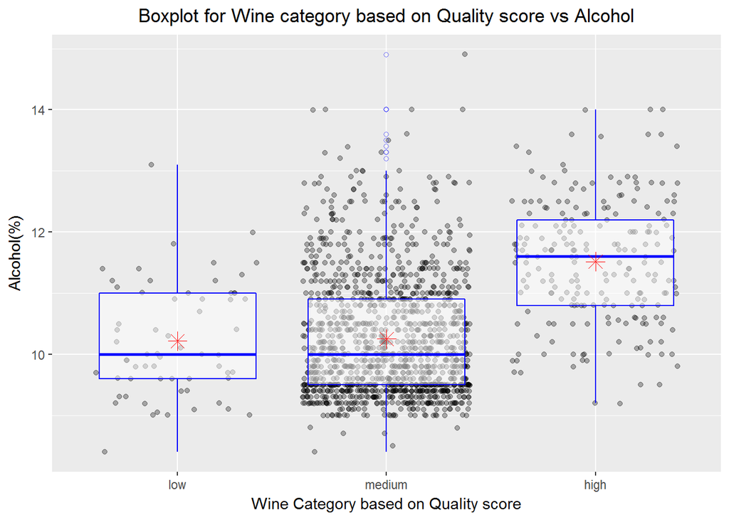

### Description One

*Alcohol* has the strongest relationship with *quality* (r-squared=0.476) and also, the most important feature in the predictor model. High Quality wines have high alcohol content compared to low quality wines.

### Plot Two

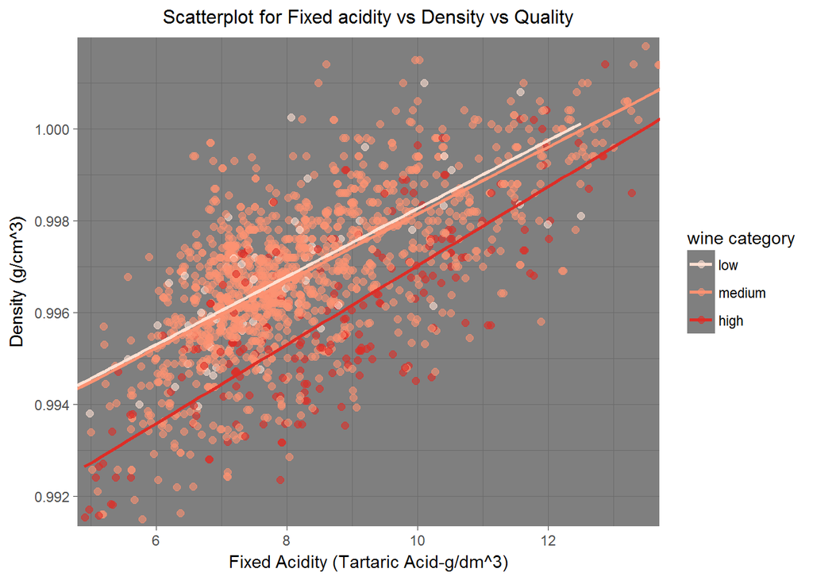

### Description Two

*Fixed Acidity* and *density* have a strong correlation(r-squared=0.668). The plot shows an interesting trend where low and medium quality wines fall more towards the upper left side of the graph and high quality wines are towards the lower right side of the graph.

### Plot Three

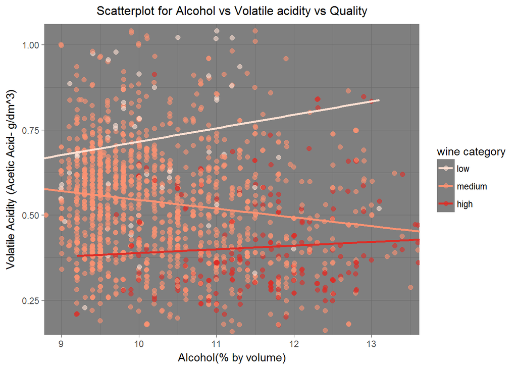

### Description Three

These two chemical attributes are the most important predictors of wine quality in the data set. It clearly shows that high and low quality wines are at opposite ends of the graph but medium quality wines are spread throughout.Higher quality wines tend to have lower volatile acidity values and higher alcohol values and lower quality wines show the opposite pattern. ——

# Reflection

This dataset contained 1,599 observations of red wines. Each wine received a quality rating and had information on 11 different chemical attributes. Most of the analysis in this project was done on the 4 feautres ( *alcohol(0.476)*, *volatile acidity(-0.39)*, *sulphates(0.251)*, *citric acid(0.226)*) that have the highest correlation with *quality*. Apart form these, some features showed interesting relationships and patterns in wine quality when plotted against each other for example, *Density* vs *Fixed acidity* (plot 2) and *Volatile* *acidity* vs *alcohol*(plot 3).

In the end , I created a regression model progressively adding the top 4 features mentioned above. *Alcohol*, *volatile acidity* and *sulphates* show highest correlation with quality but this model(m3) is able to explain only 33.6% of the existing cases. Also, addition of *citric acid* (m4) did not change the r-squared value at all. However, adding some variables with some correlation with quality improved the value t0 35.6%.

One of the major challenges in this analysis was the limitations of the dataset. The sign of quality in wines is when all components ( sweetness,acidity,tannins) blend together.*Maturity*, *colour* (depending on different grape varities), *climatic conditions* (The higher the level of sugar in the grapes before fermentation, the higher potential alcohol the wine will have, i.e. hotter countries tend to produce wines higher in alcohol), *viticulture* (way grapes are grown) and *vinification* (winemaking) are some important factors that effect the quality of wine and cannot be captured by chemical attribute variables.Also,Current data consists of samples collected from a s pecific portugal region.It will be intresting to obtain datasets across various wine making regions to eliminate any bias created by any secific qualities of the product.

Further analyis can be useful in creating a more sophisticated prediction model for wine quality if mmore data of extreme quality cases (both high and low-quality) along with non-chemical attributes can be collected.